# Assignment 3

# Based on the common fact that almost 2 rooms are matched with 1 bathroom in Melbourne, we decide to impute the missing value of “Bathroom” as a half of the missing value of “Rooms”.To avoid “bathroom” being zero, we add an value of 0.25 to the equation.

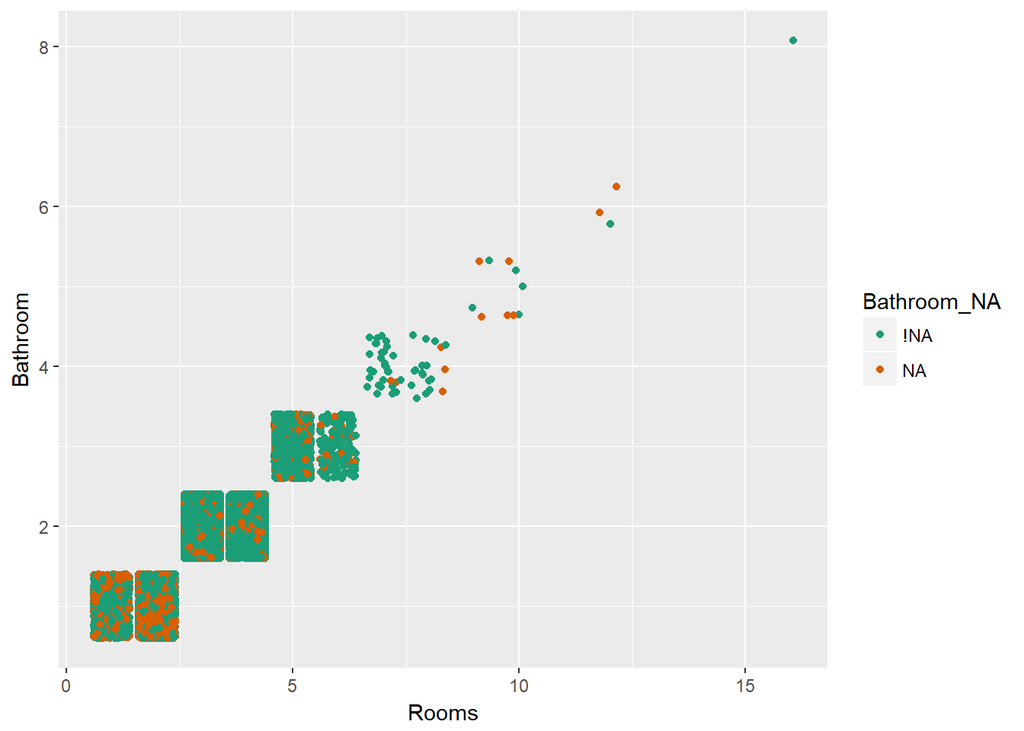

```r
ggplot(shadow2,
       aes(x = Rooms,
           y = Bathroom,colour=Bathroom_NA)) +
  geom_jitter() +
  scale_colour_brewer(palette="Dark2")
```

# As we expected, the values of “Bathroom” by imputing don’t mix with any missing values.Then, we will explain the relationship between price and different variables. One important point to notice, according to our test, there are over 25000 cases that the value of “Bedroom2” is equal to “Rooms”. Except 8000 missing value of “Bedroom2”, the number of that “Bedroom2” is different to” Rooms” is 900, making up 2.6 percent of the sample. We can assure that, in fact, “Rooms” represent the number of bedrooms. Besides, in some case the value of “Bedroom2” is 0, which is not reasonable. Then we take sampling in the “Bedroom” to compare it with its actual value and there are some errors with “Rooms” in some cases. In conclusion, we decide to keep “Rooms” but abandon “Bedroom2” because the value of “Rooms” are complete and basically accurate.

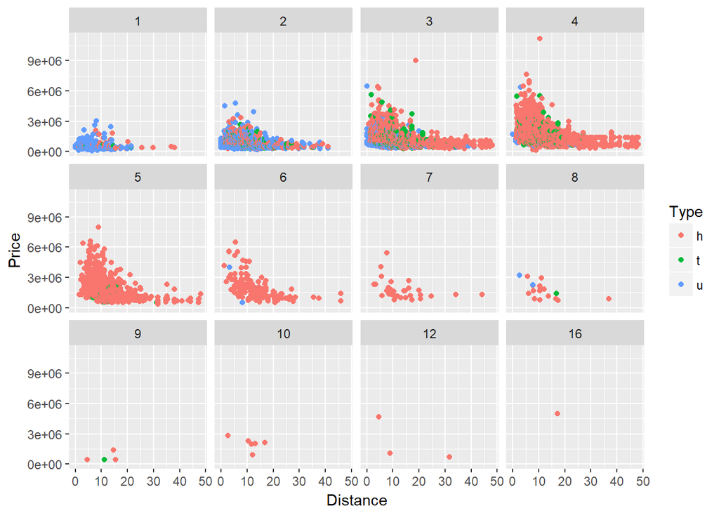

```r
ggplot(shadow2,
       aes(x = Distance,
           y = Price,colour=Type)) +
  geom_point() +
  facet_wrap(~Rooms)
```